# NLP and Sentiment Analysis based Trading Strategy

# 1. Problem Statement

The problem statement is to build a trading strategy that uses NLP to extracts the information inside the news headlines, assigns a sentiment to that and use the sentiments and the information inside the news headlines for a trading strategy.

The data used for this case study will be from three sources:

- **News headlines data compiled from RSS feeds of several news websites**: This news headlines data is complied by different news website and contains the most financially relevant news filtered by human editors. For the purpose of this study, we will only look at the headline, not the details in the story. Another important characteristic of this dataset is that the relevant tickers in the story are extracted. Our dataset contains 82,643 headlines from to 2011-05-02 to 2018-12-28
- **Yahoo finance website for the stock return:** (The return data can be obtained from other website such as yahoo finance)a
- **kaggle**: labelled data of of news sentiments obtained for a classification based sentiment analysis model. This data may not be authentic and is used only for demonstration purpose in this case study.
- Stock market lexicon created based on stock market conversations in microblogging services. The source of this lexicon is *Oliveira, Nuno, Paulo Cortez, and Nelson Areal. "Stock market sentiment lexicon acquisition using microblogging data and statistical measures." Decision Support Systems 85 (2016): 62-73.*

# 2. Getting Started- Loading the data and python packages

## 2.1. Loading the python packages

```python
#NLP libraries
from textblob import TextBlob
import spacy
import nltk
import warnings
from nltk.sentiment.vader import SentimentIntensityAnalyzer
nltk.download('vader_lexicon')
import csv
import pandas as pd

#Run the command python -m spacy download en_core_web_sm to download this
#https://spacy.io/models
import en_core_web_lg
nlp = en_core_web_lg.load()

#Libraries for processing the news headlines
from lxml import etree
import json
from io import StringIO
from os import listdir
from os.path import isfile, join
from pandas.tseries.offsets import BDay
from scipy.stats.mstats import winsorize
from copy import copy

# Libraries for Classification for modeling the sentiments
from sklearn.neural_network import MLPClassifier
from sklearn.ensemble import RandomForestClassifier
from sklearn.linear_model import LogisticRegression
from sklearn.tree import DecisionTreeClassifier
from sklearn.neighbors import KNeighborsClassifier
from sklearn.svm import SVC
from sklearn.metrics import classification_report, confusion_matrix, accuracy_score

import tensorflow as tf
from tensorflow.keras.preprocessing.text import Tokenizer
from tensorflow.keras.preprocessing.sequence import pad_sequences
from tensorflow.keras.models import Sequential
from tensorflow.keras.layers import Dense, Flatten, Dropout, Activation
from tensorflow.keras.layers import Embedding

# Load libraries
import statsmodels.api as sm
import seaborn as sns
import pandas as pd
import numpy as np
import datetime
from datetime import date
import matplotlib.pyplot as plt
import yfinance as yf

#Additional Libraries
import json
import zipfile
import os.path
import sys
```

```python
#Diable the warnings
import warnings
warnings.filterwarnings('ignore')
```

## 2.2. Loading the stock price data

The stock price data is loaded in this step from Yahoo Finance in this step. The loaded data is saved in csv for further use.

```python
tickers = ['AAPL','MSFT','AMZN','GOOG','FB','WMT','JPM','TSLA','NFLX','ADBE']
start = '2010-01-01'
end = '2018-12-31'
df_ticker_return = []
for ticker in tickers:
    ticker_yf = yf.Ticker(ticker)
    data_temp = ticker_yf.history(start = start, end = end)
    data_temp['ticker']= ticker
    df_ticker_return.append(data_temp)

# Concatenate all DataFrames in the list into a single DataFrame
df_ticker_return = pd.concat(df_ticker_return, ignore_index=True)
df_ticker_return.to_csv(r'/content/Step2.2_ReturnData.csv')
```

```
ERROR:yfinance:$FB: possibly delisted; no timezone found
```

Let us look at the details of the data

```python
df_ticker_return.head(2)
```

|  | Open | High | Low | Close | Volume | Dividends | Stock Splits | ticker | Adj Close |
| --- | --- | --- | --- | --- | --- | --- | --- | --- | --- |
| 0 | 6.437012 | 6.469283 | 6.405344 | 6.454504 | 493729600.0 | 0.0 | 0.0 | AAPL | NaN |
| 1 | 6.472301 | 6.502159 | 6.431584 | 6.465665 | 601904800.0 | 0.0 | 0.0 | AAPL | NaN |

The data contains the tickers and their return. In this next step, we clean the data make sure that the starting point is 2010 and the NAs in the data are dropped. Let us look at the news data now.

# 3. Data Preparation

## 3.1 Loading and preprocessing News Data

Let us see the content of the json file

```python
z = zipfile.ZipFile("/content/Raw Headline Data.zip", "r")
testFile=z.namelist()[10]
fileData= z.open(testFile).read()
fileDataSample = json.loads(fileData)['content'][1:500]
fileDataSample
```

```
'li class="n-box-item date-title" data-end="1305172799" data-start="1305086400" data-txt="Tuesday, December 17, 2019">Wednesday, May 11, 2011</li><li class="n-box-item sa-box-item" data-id="76179" data-ts="1305149244"><div class="media media-overflow-fix"><div class="media-left"><a class="box-ticker…
```

```python
#This function performs the json parsing given the
def jsonParser(json_data):
    xml_data = json_data['content']

    tree = etree.parse(StringIO(xml_data), parser=etree.HTMLParser())

    headlines = tree.xpath("//h4[contains(@class, 'media-heading')]/a/text()")
    assert len(headlines) == json_data['count']

    main_tickers = list(map(lambda x: x.replace('/symbol/', ''), tree.xpath("//div[contains(@class, 'media-left')]//a/@href")))
    assert len(main_tickers) == json_data['count']
    final_headlines = [''.join(f.xpath('.//text()')) for f in tree.xpath("//div[contains(@class, 'media-body')]/ul/li[1]")]
    if len(final_headlines) == 0:
        final_headlines = [''.join(f.xpath('.//text()')) for f in tree.xpath("//div[contains(@class, 'media-body')]")]
        final_headlines = [f.replace(h, '').split('\xa0')[0].strip() for f,h in zip (final_headlines, headlines)]
    return main_tickers, final_headlines
```

```python
jsonParser(json.loads(fileData))[1][1]
```

```
'Cisco Systems (NASDAQ:CSCO) falls further into the red on FQ4 guidance of $0.37-0.39 vs. $0.42 Street consensus. Sales seen flat to +2% vs. 8% Street view. CSCO recently -2.1%.'
```

As we can see that using the json parser the news headlines are extracted from the complex html format.

```python
data = None
data_df_news = []
ret = []
ret_f = []
with zipfile.ZipFile("/content/Data/Raw Headline Data.zip", "r") as z:
    for filename in z.namelist():
        #print(filename)
        try:
            #print('Running {}'.format(filename))
            with z.open(filename) as f:
                data = f.read()
                json_data = json.loads(data)
            if json_data.get('count', 0)> 10:
                #Step 1: Parse the News Jsons
                main_tickers, final_headlines = jsonParser(json_data)
                if len(final_headlines) != json_data['count']:
                    continue
                #Step 2: Prepare Future and Event Return and assign Future and Event return for each ticker.
                file_date = filename.split('/')[-1].replace('.json', '')
                file_date = date(int(file_date[:4]), int(file_date[5:7]), int(file_date[8:]))
               #Step 3: Merge all the data in a data frame
                df_dict = {'ticker': main_tickers,
                           'headline': final_headlines,
                           'date': [file_date] * len(main_tickers)
                           }
                df_f = pd.DataFrame(df_dict)
                data_df_news.append(df_f)
        except:
            pass
```

```python
data_df_news=pd.concat(data_df_news)
data_df_news.head(2)
```

|  | ticker | headline | date |
| --- | --- | --- | --- |
| 0 | DVA | Davita (NYSE:DVA): EPS of $0.96 beats by $0.01... | 2011-05-02 |
| 1 | CGNX | Cognex (NASDAQ:CGNX): EPS of $0.32 beats by $0... | 2011-05-02 |

## 3.2 Preparing the combined data

In this step we extract the event return, which is the return that corresponds to the event. We do this because at times the news is reported late and at other times it is reported after market close. Having a slightly wider window ensures that we capture the essence of the event. Event return in defined as follows: $ R_{t-1} + R_t + R_{t+1} $

Where, $ R_{t-1} $, $ R_{t+1} $ are the return before and after the news data and $ R_{t} $ is the return on the day of the news (i.e. time t)

```python
#Computing the return
df_ticker_return['ret_curr'] = df_ticker_return['Close'].pct_change()
#Computing the event return
df_ticker_return['eventRet'] = df_ticker_return['ret_curr'] + df_ticker_return['ret_curr'].shift(-1) + df_ticker_return['ret_curr'].shift(1)
df_ticker_return.reset_index(level=0, inplace=True)
df_ticker_return['date'] = pd.to_datetime(df_ticker_return['Date']).apply(lambda x: x.date())
```

Now we have all the data in place we will prepare a combined dataframe which will have the news headlines mapped to the date, event Return and stock ticker. This dataframe will be used for further analysis for sentiment analysis model and for building the trading strategy.

```python
combinedDataFrame = pd.merge(data_df_news, df_ticker_return, how='left', left_on=['date','ticker'], right_on=['date','ticker'])
combinedDataFrame = combinedDataFrame[combinedDataFrame['ticker'].isin(tickers)]
data_df = combinedDataFrame[['ticker','headline','date','eventRet','Close']]
data_df = data_df.dropna()
```

```python
data_df.head(2)
```

|  | ticker | headline | date | eventRet | Close |
| --- | --- | --- | --- | --- | --- |
| 5 | AMZN | Whole Foods (WFMI) -5.2% following a downgrade... | 2011-05-02 | 0.017650 | 201.19 |
| 11 | NFLX | Netflix (NFLX +1.1%) shares post early gains a... | 2011-05-02 | -0.013003 | 33.88 |

Let us save the data in a csv file to be used later, so that the data processing step can be skipped everytime we are looking into analysis.

```python
data_df.dropna().to_csv(r'/content/Step3_NewsAndReturnData.csv', sep='|', index=False)
```

## 3.3 Loading the preprocessed data

#### Start from this step in case you dont want to run the previous preprocessing steps

```python
data_df = pd.read_csv(r'/content/Step3_NewsAndReturnData.csv', sep='|')
data_df = data_df.dropna()
```

```python
print(data_df.shape, data_df.ticker.unique().shape)
```

```
(2759, 5) (10,)
```

# 4 Evaluate Models for Sentiment Analysis

In this section we will go through following three different approaches of getting the sentiments for the news which we will use for building the trading strategy.

## 4.1 - Predefined model-TextBlob package

```python
text1 = "Bayer (OTCPK:BAYRY) started the week up 3.5% to €74/share in Frankfurt, touching their \
highest level in 14 months, after the U.S. government said a $25M glyphosate decision against the \
company should be reversed."
```

```python
TextBlob(text1).sentiment.polarity
```

```
0.5
```

The sentiment polarity is a number between -1 (Very Negative) and +1 (Very Positive). We apply this on all headline we have in the data processed in the previous step. Let us compute the sentiment for all the headlines in the data

```python
data_df['sentiment_textblob'] = [TextBlob(s).sentiment.polarity for s in data_df['headline']]
```

Let us analyse the scatterplot of the sentiments and the return.

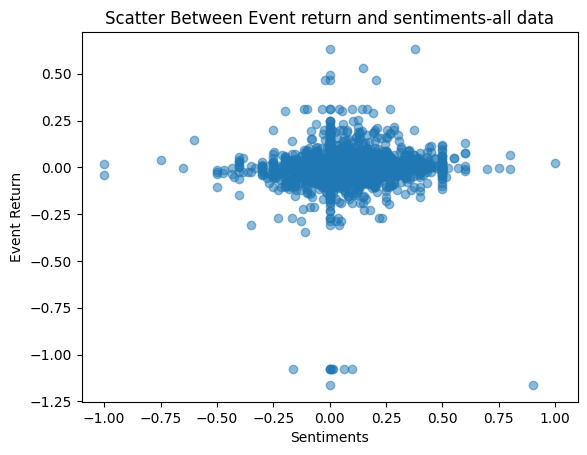

```python
plt.scatter(data_df['sentiment_textblob'],data_df['eventRet'], alpha=0.5)
plt.title('Scatter Between Event return and sentiments-all data')
plt.ylabel('Event Return')
plt.xlabel('Sentiments')
plt.show()
```

```python
corrlation = data_df['eventRet'].corr(data_df['sentiment_textblob'])
print(corrlation)
```

```
0.042749340813834226
```

The correlation is positive, which means that news with positive sentiments lead to positive return and is expected. However,the correlation isn't very high.

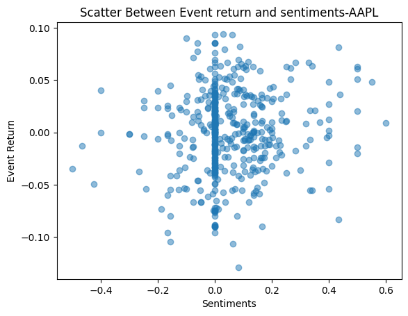

```python
data_df_stock  = data_df[data_df['ticker'] == 'AAPL']
plt.scatter(data_df_stock['sentiment_textblob'],data_df_stock['eventRet'], alpha=0.5)
plt.title('Scatter Between Event return and sentiments-AAPL')
plt.ylabel('Event Return')
plt.xlabel('Sentiments')
plt.show()
```

Overall, from the results we can see that there isn't a strong correlation between the news and the sentiments. Also, there are a lot of sentiments centred around 0.

```python
text = "Bayer (OTCPK:BAYRY) started the week up 3.5% to €74/share in Frankfurt, touching their highest level in 14 months, after the U.S. government said a $25M glyphosate decision against the company should be reversed."
TextBlob(text).sentiment_assessments
```

```
Sentiment(polarity=0.5, subjectivity=0.5, assessments=[(['touching'], 0.5, 0.5, None)])
```

We see that the statement has a positive sentiment of .5 but looking at the words that give rise to the sentiments, the word "touching" and not "high" causes positive sentiment.

## 4.2 - Supervised Learning-Classification algorithms

In this step, we develop customised model for sentiment analysis, based on available labelled data. The label data for this is obtained from kaggle website. Let us look at the data.

```python
sentiments_data = pd.read_csv(r'/content/LabelledNewsData.csv',encoding = "ISO-8859-1")
```

```python
sentiments_data.head(1)
```

|  | datetime | headline | ticker | sentiment |
| --- | --- | --- | --- | --- |
| 0 | 1/16/2020 5:25 | $MMM fell on hard times but could be set to re... | MMM | 0 |

```python
print(sentiments_data.shape[0],',', sentiments_data.ticker.unique().shape[0])
```

```
9470 , 30
```

The data has headlines for the news across 30 different stocks, with total 9470 rows, and has sentiments lacelled 0 and 1. The headlines are already in almost cleaned. We perform the classification steps.

In order to run a supervised learning model, we first need to convert the news headlines into feature representation.

```python
#word-embedding
all_vectors = np.array([np.array([token.vector for token in nlp(s) ]).mean(axis=0)*np.ones((300)) \
                           for s in sentiments_data['headline']])
```

Now that we have prepared the independent variable we train the classification model. We first divide the data into training set and test set and futher run the key classification models.

```python
# split out validation dataset for the end
Y= sentiments_data["sentiment"]
X = all_vectors

from sklearn.model_selection import train_test_split, KFold, cross_val_score, GridSearchCV
validation_size = 0.3
seed = 7
X_train, X_test, Y_train, Y_test = train_test_split(X, Y, test_size=validation_size, random_state=seed)

# test options for classification
num_folds = 10
seed = 7
scoring = 'accuracy'

# spot check the algorithms
models = []
models.append(('LR', LogisticRegression()))
models.append(('KNN', KNeighborsClassifier()))
models.append(('CART', DecisionTreeClassifier()))
models.append(('SVM', SVC()))
#Ensable Models
models.append(('RF', RandomForestClassifier()))
```

Running all the classification models

```python
results = []
names = []
kfold_results = []
test_results = []
train_results = []
for name, model in models:
    kfold = KFold(n_splits=num_folds, shuffle=True, random_state=seed)
    cv_results = cross_val_score(model, X_train, Y_train, cv=kfold, scoring=scoring)
    results.append(cv_results)
    names.append(name)
    res = model.fit(X_train, Y_train)
    train_result = accuracy_score(res.predict(X_train), Y_train)
    train_results.append(train_result)
    test_result = accuracy_score(res.predict(X_test), Y_test)
    test_results.append(test_result)

    msg = "%s: %f (%f) %f %f" % (name, cv_results.mean(), cv_results.std(), train_result, test_result)
    print(msg)
    print(classification_report(res.predict(X_test), Y_test))
```

```
LR: 0.878714 (0.009366) 0.896063 0.875748
              precision    recall  f1-score   support

           0       0.85      0.86      0.86      1213
           1       0.90      0.89      0.89      1628

    accuracy                           0.88      2841
   macro avg       0.87      0.87      0.87      2841
weighted avg       0.88      0.88      0.88      2841

KNN: 0.791071 (0.012103) 0.869060 0.787751
              precision    recall  f1-score   support

           0       0.76      0.76      0.76      1233
           1       0.81      0.81      0.81      1608

    accuracy                           0.79      2841
   macro avg       0.78      0.78      0.78      2841
weighted avg       0.79      0.79      0.79      2841

CART: 0.694372 (0.013862) 0.999698 0.680042
              precision    recall  f1-score   support

           0       0.61      0.64      0.62      1187
           1       0.73      0.71      0.72      1654

    accuracy                           0.68      2841
   macro avg       0.67      0.67      0.67      2841
weighted avg       0.68      0.68      0.68      2841

SVM: 0.895308 (0.010371) 0.919897 0.896515
              precision    recall  f1-score   support

           0       0.88      0.88      0.88      1234
           1       0.91      0.91      0.91      1607

    accuracy                           0.90      2841
   macro avg       0.89      0.89      0.89      2841
weighted avg       0.90      0.90      0.90      2841

RF: 0.813699 (0.011192) 0.999698 0.819782
              precision    recall  f1-score   support

           0       0.70      0.86      0.77      1014
           1       0.91      0.80      0.85      1827

    accuracy                           0.82      2841
   macro avg       0.81      0.83      0.81      2841
weighted avg       0.84      0.82      0.82      2841
```

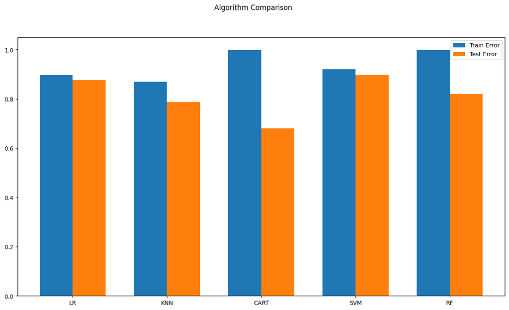

```python
# compare algorithms
from matplotlib import pyplot
fig = pyplot.figure()
ind = np.arange(len(names))  # the x locations for the groups
width = 0.35  # the width of the bars
fig.suptitle('Algorithm Comparison')
ax = fig.add_subplot(111)
pyplot.bar(ind - width/2, train_results,  width=width, label='Train Error')
pyplot.bar(ind + width/2, test_results, width=width, label='Test Error')
fig.set_size_inches(15,8)
pyplot.legend()
ax.set_xticks(ind)
ax.set_xticklabels(names)
pyplot.show()
```

```python
model = SVC()
model.fit(X_train, Y_train)
```

```
SVC()
```

```python
train_result= accuracy_score(model.predict(X_train), Y_train)
# Test results
test_result= accuracy_score(model.predict(X_test), Y_test)
```

Computing the accuracy and confusion metrics.

```python
print(train_result,test_result)
```

```
0.9198974204254036 0.8965153115100317
```

```python
confusion_matrix(model.predict(X_test), Y_test)
```

```
array([[1087,  147],
       [ 147, 1460]])
```

```python
train_results.append(train_result);test_results.append(test_result)
```

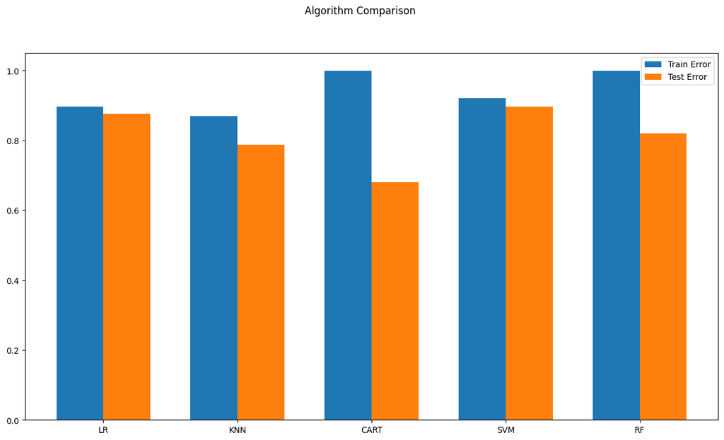

```python
from matplotlib import pyplot
import numpy as np

fig = pyplot.figure()
ind = np.arange(len(names))
width = 0.35
fig.suptitle('Algorithm Comparison')
ax = fig.add_subplot(111)

# Ensure train_results and test_results have the same length as names
num_algorithms = len(names)
train_results = train_results[:num_algorithms]
test_results = test_results[:num_algorithms]

pyplot.bar(ind - width/2, train_results,  width=width, label='Train Error')
pyplot.bar(ind + width/2, test_results, width=width, label='Test Error')
fig.set_size_inches(15,8)
pyplot.legend()
ax.set_xticks(ind)
ax.set_xticklabels(names)
pyplot.show()
```

```python
vocabulary_size = 20000
tokenizer = Tokenizer(num_words= vocabulary_size)
tokenizer.fit_on_texts(sentiments_data['headline'])
sequences = tokenizer.texts_to_sequences(sentiments_data['headline'])
```

```python
sequences_SVC = tokenizer.texts_to_sequences(data_df['headline'])
X_SVC = pad_sequences(sequences_SVC, maxlen=300)
```

```python
Y_SVC = model.predict(X_SVC)
```

```python
data_df['sentiment_SVC'] = Y_SVC
```

```python
corrlation = data_df['eventRet'].corr(data_df['sentiment_SVC'])
print(corrlation)
```

```
nan
```

```python
data_df.head(1)
```

|  | ticker | headline | date | eventRet | Close | sentiment_textblob | sentiment_SVC |
| --- | --- | --- | --- | --- | --- | --- | --- |
| 0 | AMZN | Whole Foods (WFMI) -5.2% following a downgrade... | 2011-05-02 | 0.01765 | 201.19 | 0.2625 | 1 |

## 4.3 - Unsupervised - Model based on financial lexicon

Lexicons are special dictionaries or vocabularies that have been created for analyzing sentiments. VADER (Valence Aware Dictionary for Entiment Reasoning) is a pre-built sentiment analysis model included in the NLTK package.

```python
# stock market lexicon
sia = SentimentIntensityAnalyzer()
stock_lex = pd.read_csv('Data\LexiconData.csv')
stock_lex['sentiment'] = (stock_lex['Aff_Score'] + stock_lex['Neg_Score'])/2
stock_lex = dict(zip(stock_lex.Item, stock_lex.sentiment))
stock_lex = {k:v for k,v in stock_lex.items() if len(k.split(' '))==1}
stock_lex_scaled = {}
for k, v in stock_lex.items():
    if v > 0:
        stock_lex_scaled[k] = v / max(stock_lex.values()) * 4
    else:
        stock_lex_scaled[k] = v / min(stock_lex.values()) * -4

final_lex = {}
final_lex.update(stock_lex_scaled)
final_lex.update(sia.lexicon)
sia.lexicon = final_lex
```

Example of extracting sentiment score for a sentence:

```python
text = "AAPL is trading higher after reporting its October sales rose 12.6% M/M. It has seen a 20%+ jump in orders"
```

```python
sia.polarity_scores(text)['compound']
```

```
0.4535
```

Now we extract the sentiment for the entire dataset.

```python
vader_sentiments = pd.np.array([sia.polarity_scores(s)['compound'] for s in data_df['headline']])
vader_sentiments.shape
```

```
(2759,)
```

```python
data_df['sentiment_lex'] = vader_sentiments
```

```python
corrlation = data_df['eventRet'].corr(data_df['sentiment_lex'])
print(corrlation)
```

```
0.1047785005800468
```

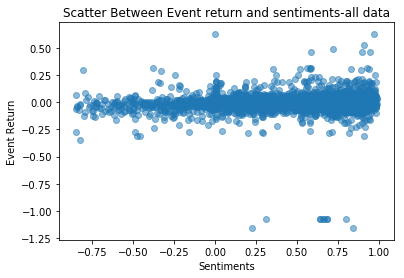

```python
plt.scatter(data_df['sentiment_lex'],data_df['eventRet'], alpha=0.5)
plt.title('Scatter Between Event return and sentiments-all data')
plt.ylabel('Event Return')
plt.xlabel('Sentiments')
plt.show()
```

We don's see many high returns for lower sentiments, but the data may not be very clear. Let us look at the result for one of the stock tickers.

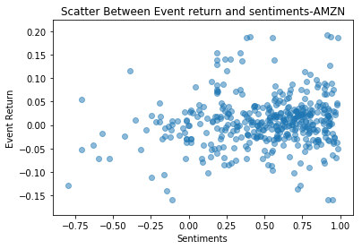

```python
data_df_stock  = data_df[data_df['ticker'] == 'AMZN']
plt.scatter(data_df_stock['sentiment_lex'],data_df_stock['eventRet'], alpha=0.5)
plt.title('Scatter Between Event return and sentiments-AMZN')
plt.ylabel('Event Return')
plt.xlabel('Sentiments')
plt.show()
```

We see a positive correlation between the event return and sentiments. We will look deeper into the comparison of different types of the sentiment analysis in the next section.

```python
data_df.to_csv(r'/content/Step4_DataWithSentimentsResults.csv', sep='|', index=False)
```

## 4.4 Exploratory Data Analysis and comparison

```python
data_df = pd.read_csv(r'/content/Step4_DataWithSentimentsResults.csv', sep='|')
data_df = data_df[data_df['ticker'].isin(tickers)]
```

Let us look at the sample headlines and the the sentiments from three different methodology, followed by the analysis using visualization.

```python
data_new_df_stock=data_df[data_df['ticker']== 'NFLX'][['ticker','headline','sentiment_textblob','sentiment_LSTM','sentiment_lex']]
from pandas import option_context

with option_context('display.max_colwidth', 400):
    display(data_new_df_stock.head(1))
```

[output not shown]

Looking at one of the headlines, the sentiment from this sentence is positive.

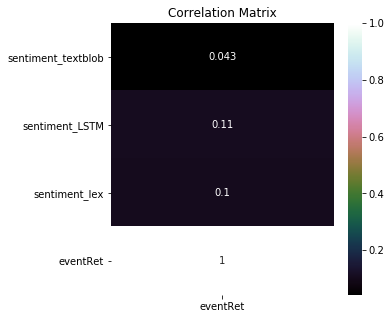

```python
correlation = data_df[['sentiment_textblob','sentiment_LSTM','sentiment_lex','eventRet']].dropna(axis=0).corr()

plt.figure(figsize=(5,5))
plt.title('Correlation Matrix')
sns.heatmap(correlation[['eventRet']], vmax=1, annot=True,cmap='cubehelix')
```

All the sentiments have positive relationship with the return which is intuitive and expected.

```python
corr_data = []
for ticker in data_df['ticker'].unique():
    data_new_df_stock=data_df[data_df['ticker']==ticker]
    #Only look for the stocks with sufficient data
    if data_new_df_stock.shape[0] > 40 :
        corr_textblob= data_new_df_stock['eventRet'].corr(data_new_df_stock['sentiment_textblob'])
        corr_LSTM = data_new_df_stock['eventRet'].corr(data_new_df_stock['sentiment_LSTM'])
        corr_lex = data_new_df_stock['eventRet'].corr(data_new_df_stock['sentiment_lex'])
        corr_data.append([ticker,corr_textblob, corr_LSTM, corr_lex])
        #print(ticker,corr_vader, corr_LSTM, corr_textblob)
    else:
        continue
```

```python
corr_df = pd.DataFrame(corr_data, columns =  ['ticker','corr_textblob','corr_LSTM','corr_lex'])
corr_df=corr_df.set_index('ticker')
corr_df.head(1)
```

| ticker | corr_textblob | corr_LSTM | corr_lex |
| --- | --- | --- | --- |
| AMZN | 0.01983 | 0.134878 | 0.138296 |

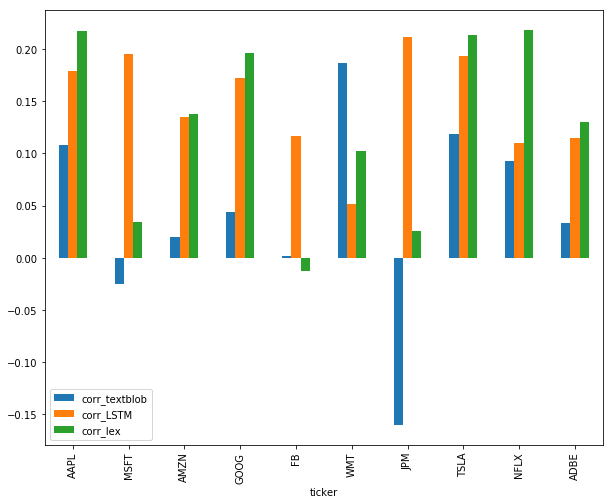

```python
#corr_df.to_csv("correlation.csv")
#tickers = ['AAPL','MSFT','AMZN','GOOG','BABA','FB','WMT','V','JPM','TSLA']
corr_df.loc[tickers].plot.bar(figsize = (10,8))
plt.show()
```

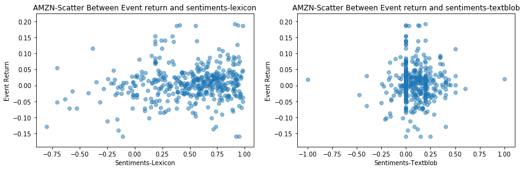

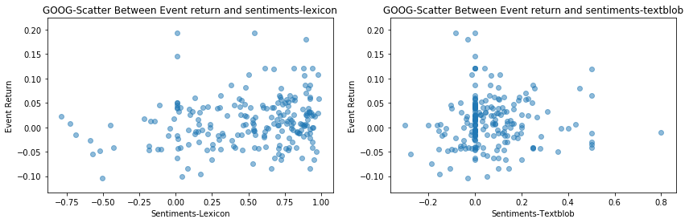

```python
#tickers = corr_df.nlargest(5,'corr_lex').index
for ticker in tickers[2:4]:
    data_df_stock  = data_df[data_df['ticker'] == ticker]
    fig = plt.figure(figsize=(14, 4), constrained_layout=False)

    plt.subplot(1, 2, 1)
    plt.scatter(data_df_stock['sentiment_lex'],data_df_stock['eventRet'], alpha=0.5)
    plt.title(ticker + '-Scatter Between Event return and sentiments-lexicon')
    plt.ylabel('Event Return')
    plt.xlabel('Sentiments-Lexicon')


    plt.subplot(1, 2, 2)
    plt.scatter(data_df_stock['sentiment_textblob'],data_df_stock['eventRet'], alpha=0.5)
    plt.title(ticker + '-Scatter Between Event return and sentiments-textblob')
    plt.ylabel('Event Return')
    plt.xlabel('Sentiments-Textblob')
    plt.show()
```

The lexicon based sentiments on the left definitely shows a positive relationship between the sentiments and return. We use lexicon based sentiments for the trading strategy in the next step.

# 5. Model Evaluation- Building a Trading Strategy

The sentiment data can be used in different ways for the trading strategy. Sentiment scores can be used as a directional signal and ideally create a long-short portfolio, by buying the stocks with positive score and selling the stocks with negative score. The sentiments can also be used as additional features over and above other features(such as correlated stocks, technical indicators) in a supervised learning model to predict the price or come up with a trading strategy.

In the trading strategy in this case study we buy and sell stock as per the current stock sentiments :

- Buy a stock when the change in sentiment score (Current sentiment score - previous sentiment score) is greater than .5 and sell a stock when the change in sentiment score is less than -.5.
- Additionally, we check for 15 days moving average while buying and selling and buy or sell in a unit of 100.

Obviusly, there can be many ways to create the trading strategy based in sentiments, by varying the threshold, or changing the number of units based on the initial cash available.

We use lexicon based sentiments for the trading strategy.

## 5.1. Setting up the strategy

Here we use backtrader which is a Python based API for writing and backtesting trading strategy. . Backtrader allows you to focus on writing reusable trading strategies, indicators and analyzers instead of having to spend time building infrastructure. we have a convenient framework to backtest and write our trading strategy. We used the Quickstart code in the docs (i.e. Refer to https://www.backtrader.com/docu/quickstart/quickstart/) as a base and modified it to include the sentiment scores.

We imlement a simple strategy to buy if the previous day’s sentiment score increases by 0.5 from the last day and sell if it decreases by 0.5.

The following function contains two classes:

- Sentiment:
- SentimentStrat: The "next" function of this class implements the actual trading strategy.

```python
import backtrader as bt
import backtrader.indicators as btind
import backtrader.analyzers as btanalyzers

class Sentiment(bt.Indicator):
    lines = ('sentiment',)
    plotinfo = dict(
        plotymargin=0.5,
        plothlines=[0],
        plotyticks=[1.0, 0, -1.0])

    def next(self):
        self.sentiment = 0.0
        self.date = self.data.datetime
        date = bt.num2date(self.date[0]).date()
        prev_sentiment = self.sentiment
        if date in date_sentiment:
            self.sentiment = date_sentiment[date]
        self.lines.sentiment[0] = self.sentiment


class SentimentStrat(bt.Strategy):
    params = (
        ('period', 15),
        ('printlog', True),
    )

    def log(self, txt, dt=None, doprint=False):
        ''' Logging function for this strategy'''
        if self.params.printlog or doprint:
            dt = dt or self.datas[0].datetime.date(0)
            print('%s, %s' % (dt.isoformat(), txt))

    def __init__(self):
        # Keep a reference to the "close" line in the data[0] dataseries
        self.dataclose = self.datas[0].close
        # Keep track of pending orders
        self.order = None
        self.buyprice = None
        self.buycomm = None
        self.sma = bt.indicators.SimpleMovingAverage(
            self.datas[0], period=self.params.period)
        self.date = self.data.datetime
        self.sentiment = None
        Sentiment(self.data)
        self.plotinfo.plot = False


    def notify_order(self, order):
        if order.status in [order.Submitted, order.Accepted]:
            # Buy/Sell order submitted/accepted to/by broker - Nothing to do
            return

        # Check if an order has been completed
        # Attention: broker could reject order if not enough cash
        if order.status in [order.Completed]:
            if order.isbuy():
                self.log(
                    'BUY EXECUTED, Price: %.2f, Cost: %.2f, Comm %.2f' %
                    (order.executed.price,
                     order.executed.value,
                     order.executed.comm))
                self.buyprice = order.executed.price
                self.buycomm = order.executed.comm
            else:  # Sell
                self.log('SELL EXECUTED, Price: %.2f, Cost: %.2f, Comm %.2f' %
                         (order.executed.price,
                          order.executed.value,
                          order.executed.comm))

            self.bar_executed = len(self)

        elif order.status in [order.Canceled, order.Margin, order.Rejected]:
            self.log('Order Canceled/Margin/Rejected')

        # Write down: no pending order
        self.order = None

    def notify_trade(self, trade):
        if not trade.isclosed:
            return

        self.log('OPERATION PROFIT, GROSS %.2f, NET %.2f' %
                 (trade.pnl, trade.pnlcomm))

    ### Main Strat ###
    def next(self):
        date = bt.num2date(self.date[0]).date()
        prev_sentiment = self.sentiment
        if date in date_sentiment:
            self.sentiment = date_sentiment[date]

        # Check if an order is pending. if yes, we cannot send a 2nd one
        if self.order:
            return
        # If not in the market and previous sentiment not none
        if not self.position and prev_sentiment:
            # buy if current close more than sma AND sentiment increased by >= 0.5
            if self.dataclose[0] > self.sma[0] and self.sentiment - prev_sentiment >= 0.5:
                self.log('Previous Sentiment %.2f, New Sentiment %.2f BUY CREATE, %.2f' % (prev_sentiment, self.sentiment, self.dataclose[0]))
                self.order = self.buy()

        # Already in the market and previous sentiment not none
        elif prev_sentiment:
            # sell if current close less than sma AND sentiment decreased by >= 0.5
            if self.dataclose[0] < self.sma[0] and self.sentiment - prev_sentiment <= -0.5:
                self.log('Previous Sentiment %.2f, New Sentiment %.2f SELL CREATE, %.2f' % (prev_sentiment, self.sentiment, self.dataclose[0]))
                self.order = self.sell()

    def stop(self):
        self.log('(MA Period %2d) Ending Value %.2f' %
                 (self.params.period, self.broker.getvalue()), doprint=True)
```

### Function for running the trading strategy

Now, we write a generic function to run the strategy for any stock. We specified the “ticker” stock feeds to be pulled from Yahoo Finance, set an initial amount of $100,000, a fixed size of 100 lots per trade.

```python
def run_strategy(ticker, start, end):
    print(ticker)
    ticker = yf.Ticker(ticker)
    df_ticker = ticker.history(start = start, end = end)

    cerebro = bt.Cerebro()
    # Add the data
    cerebro.addstrategy(SentimentStrat)
    data = bt.feeds.PandasData(dataname=df_ticker)
    cerebro.adddata(data)
    start = 100000.0
    cerebro.broker.setcash(start)
    cerebro.addsizer(bt.sizers.FixedSize, stake=100)
    print('Starting Portfolio Value: %.2f' % start)
    plt.rcParams['figure.figsize']=[10,6]
    plt.rcParams["font.size"]="12"
    cerebro.run()
    cerebro.plot(volume=False, iplot=True, plotname= ticker)
    end = cerebro.broker.getvalue()
    print('Start Portfolio value: %.2f\nFinal Portfolio Value: %.2f\nProfit: %.2f\n' \
          % (start, end, end - start))
    return float(df_ticker['Close'][0]), (end - start)
```

## 5.2. Results for Individual Stocks

First running the strategy for google

```
GOOG
Starting Portfolio Value: 100000.00
2012-04-12, Previous Sentiment 0.24, New Sentiment 0.80 BUY CREATE, 324.29
2012-04-13, BUY EXECUTED, Price: 322.57, Cost: 32257.00, Comm 0.00
2012-10-18, Previous Sentiment 0.98, New Sentiment 0.08 SELL CREATE, 346.20
2012-10-19, SELL EXECUTED, Price: 351.47, Cost: 32257.00, Comm 0.00
2012-10-19, OPERATION PROFIT, GROSS 2890.00, NET 2890.00
2013-01-10, Previous Sentiment 0.08, New Sentiment 0.80 BUY CREATE, 369.36
2013-01-11, BUY EXECUTED, Price: 369.61, Cost: 36961.00, Comm 0.00
2014-07-17, Previous Sentiment 0.73, New Sentiment -0.22 SELL CREATE, 572.16
2014-07-18, SELL EXECUTED, Price: 591.38, Cost: 36961.00, Comm 0.00
2014-07-18, OPERATION PROFIT, GROSS 22177.00, NET 22177.00
2014-07-18, Previous Sentiment -0.22, New Sentiment 0.77 BUY CREATE, 593.45
2014-07-21, BUY EXECUTED, Price: 590.13, Cost: 59013.00, Comm 0.00
2014-09-12, Previous Sentiment 0.66, New Sentiment -0.05 SELL CREATE, 574.04
2014-09-15, SELL EXECUTED, Price: 571.37, Cost: 59013.00, Comm 0.00
2014-09-15, OPERATION PROFIT, GROSS -1876.00, NET -1876.00
2015-07-17, Previous Sentiment 0.01, New Sentiment 0.90 BUY CREATE, 672.93
2015-07-20, BUY EXECUTED, Price: 659.24, Cost: 65924.00, Comm 0.00
2015-08-24, Previous Sentiment 0.91, New Sentiment -0.51 SELL CREATE, 589.61
2015-08-25, SELL EXECUTED, Price: 614.91, Cost: 65924.00, Comm 0.00
2015-08-25, OPERATION PROFIT, GROSS -4433.00, NET -4433.00
2015-10-22, Previous Sentiment -0.79, New Sentiment 0.73 BUY CREATE, 651.79
2015-10-23, BUY EXECUTED, Price: 727.50, Cost: 72750.00, Comm 0.00
2017-09-25, Previous Sentiment 0.69, New Sentiment 0.14 SELL CREATE, 920.97
2017-09-26, SELL EXECUTED, Price: 923.72, Cost: 72750.00, Comm 0.00
2017-09-26, OPERATION PROFIT, GROSS 19622.00, NET 19622.00
2017-10-27, Previous Sentiment 0.01, New Sentiment 0.60 BUY CREATE, 1019.27
2017-10-30, BUY EXECUTED, Price: 1014.00, Cost: 101400.00, Comm 0.00
2018-04-09, Previous Sentiment 0.54, New Sentiment -0.45 SELL CREATE, 1015.45
2018-04-10, SELL EXECUTED, Price: 1026.44, Cost: 101400.00, Comm 0.00
2018-04-10, OPERATION PROFIT, GROSS 1244.00, NET 1244.00
2018-04-23, Previous Sentiment 0.03, New Sentiment 0.87 BUY CREATE, 1067.45
2018-04-24, BUY EXECUTED, Price: 1052.00, Cost: 105200.00, Comm 0.00
2018-09-04, Previous Sentiment 0.76, New Sentiment 0.01 SELL CREATE, 1197.00
2018-09-05, SELL EXECUTED, Price: 1193.80, Cost: 105200.00, Comm 0.00
2018-09-05, OPERATION PROFIT, GROSS 14180.00, NET 14180.00
2018-10-01, Previous Sentiment 0.01, New Sentiment 0.88 BUY CREATE, 1195.31
2018-10-02, BUY EXECUTED, Price: 1190.96, Cost: 119096.00, Comm 0.00
2018-10-05, Previous Sentiment 0.88, New Sentiment 0.31 SELL CREATE, 1157.35
2018-10-08, SELL EXECUTED, Price: 1150.11, Cost: 119096.00, Comm 0.00
2018-10-08, OPERATION PROFIT, GROSS -4085.00, NET -4085.00
2018-12-11, (MA Period 15) Ending Value 149719.00
```

```
Start Portfolio value: 100000.00
Final Portfolio Value: 149719.00
Profit: 49719.00
```

```
(331.46, 49719.0)
```

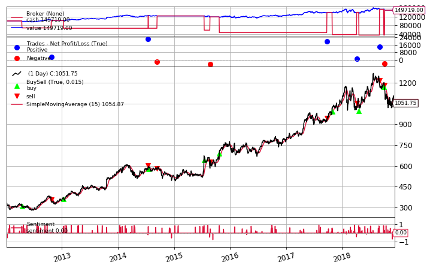

```python
ticker = 'GOOG'
date_sentiment=data_df[data_df['ticker'].isin([ticker])]
date_sentiment=date_sentiment[['date','sentiment_lex']]
date_sentiment['date']=pd.to_datetime(date_sentiment['date'], format='%Y-%m-%d').dt.date
date_sentiment=date_sentiment.set_index('date')['sentiment_lex']
date_sentiment=date_sentiment.to_dict()
run_strategy(ticker, start = '2012-01-01', end = '2018-12-12')
```

- Top Panel : Top panel is the cash value observer which as the name implies keeps track of the Cash and total portolio Value (including cash) during the life of the backtesting run. As we can see that we started with 100000.00 and final value at the end is 149719.00 as shown in this panel.
- Second Panel : This panel is Trade Observer which shows, at the end of a trade, the actual Profit and Loss. A trade is defined as opening a position and taking the position back to 0 (directly or crossing over from long to short or short to long). Five out of eight actions of buy and sell are profitable for the strategy.
- Third Panel : This panel is Buy Sell observer which plots (on top of the prices) where buy and sell operations have taken place. In general we see that (specially around 2018) the buy action takes place when the stock price is increasing and the sell action takes place when the stock price has started declining.
- Bottom Panel : This panel shows the sentiment score.

Now we choose one of the days on which buy was triggered and we look at the news on that data and previous day.

```python
GOOG_ticker= data_df[data_df['ticker'].isin([ticker])]
New= list(GOOG_ticker[GOOG_ticker['date'] ==  '2015-07-17']['headline'])
Old= list(GOOG_ticker[GOOG_ticker['date'] ==  '2015-07-16']['headline'])
print("Current News:",New,"\n\n","Previous News:", Old)
```

```
Current News: ["Axiom Securities has upgraded Google (GOOG +13.4%, GOOGL +14.8%) to Buy following the company's Q2 beat and investor-pleasing comments about spending discipline, potential capital returns, and YouTube/mobile growth. MKM has launched coverage at Buy, and plenty of other firms have hik…

 Previous News: ["While Google's (GOOG, GOOGL) Q2 revenue slightly missed estimates when factoring traffic acquisitions costs (TAC), its ex-TAC revenue of $14.35B was slightly above a $14.3B consensus. The reason: TAC fell to 21% of ad revenue from Q1's 22% and Q2 2014's 23%. That also, of course, h…
```

Clearly the News on the current day has positive sentiment as compared to the news at the previous day causing the buy to be triggered. Now, we run the strategy for Facebook.

```
FB
Starting Portfolio Value: 100000.00
2012-11-14, Previous Sentiment -0.82, New Sentiment 0.71 BUY CREATE, 22.36
2012-11-15, BUY EXECUTED, Price: 22.34, Cost: 2234.00, Comm 0.00
2013-03-13, Previous Sentiment 0.95, New Sentiment -0.25 SELL CREATE, 27.08
2013-03-14, SELL EXECUTED, Price: 27.10, Cost: 2234.00, Comm 0.00
2013-03-14, OPERATION PROFIT, GROSS 476.00, NET 476.00
2013-04-10, Previous Sentiment -0.25, New Sentiment 0.94 BUY CREATE, 27.57
2013-04-11, BUY EXECUTED, Price: 27.48, Cost: 2748.00, Comm 0.00
2013-11-18, Previous Sentiment 0.98, New Sentiment 0.40 SELL CREATE, 45.83
2013-11-19, SELL EXECUTED, Price: 46.26, Cost: 2748.00, Comm 0.00
2013-11-19, OPERATION PROFIT, GROSS 1878.00, NET 1878.00
2014-01-30, Previous Sentiment 0.01, New Sentiment 0.82 BUY CREATE, 61.08
2014-01-31, BUY EXECUTED, Price: 60.47, Cost: 6047.00, Comm 0.00
2014-12-16, Previous Sentiment 0.68, New Sentiment -0.39 SELL CREATE, 74.69
2014-12-17, SELL EXECUTED, Price: 75.01, Cost: 6047.00, Comm 0.00
2014-12-17, OPERATION PROFIT, GROSS 1454.00, NET 1454.00
2014-12-22, Previous Sentiment -0.39, New Sentiment 0.73 BUY CREATE, 81.45
2014-12-23, BUY EXECUTED, Price: 82.02, Cost: 8202.00, Comm 0.00
2016-04-27, Previous Sentiment 0.91, New Sentiment 0.01 SELL CREATE, 108.89
2016-04-28, SELL EXECUTED, Price: 119.58, Cost: 8202.00, Comm 0.00
2016-04-28, OPERATION PROFIT, GROSS 3756.00, NET 3756.00
2016-07-06, Previous Sentiment -0.11, New Sentiment 0.81 BUY CREATE, 116.70
2016-07-07, BUY EXECUTED, Price: 116.63, Cost: 11663.00, Comm 0.00
2016-11-18, Previous Sentiment 0.78, New Sentiment -0.13 SELL CREATE, 117.02
2016-11-21, SELL EXECUTED, Price: 118.20, Cost: 11663.00, Comm 0.00
2016-11-21, OPERATION PROFIT, GROSS 157.00, NET 157.00
2016-11-21, Previous Sentiment -0.13, New Sentiment 0.83 BUY CREATE, 121.77
2016-11-22, BUY EXECUTED, Price: 122.40, Cost: 12240.00, Comm 0.00
2016-12-01, Previous Sentiment 0.83, New Sentiment -0.01 SELL CREATE, 115.10
2016-12-02, SELL EXECUTED, Price: 115.11, Cost: 12240.00, Comm 0.00
2016-12-02, OPERATION PROFIT, GROSS -729.00, NET -729.00
2018-04-10, Previous Sentiment 0.03, New Sentiment 0.55 BUY CREATE, 165.04
2018-04-11, BUY EXECUTED, Price: 165.36, Cost: 16536.00, Comm 0.00
2018-08-16, Previous Sentiment 0.80, New Sentiment -0.23 SELL CREATE, 174.70
2018-08-17, SELL EXECUTED, Price: 174.50, Cost: 16536.00, Comm 0.00
2018-08-17, OPERATION PROFIT, GROSS 914.00, NET 914.00
2018-12-03, Previous Sentiment -0.63, New Sentiment 0.47 BUY CREATE, 141.09
2018-12-04, BUY EXECUTED, Price: 140.73, Cost: 14073.00, Comm 0.00
2018-12-11, (MA Period 15) Ending Value 108041.00
```

```
Start Portfolio value: 100000.00
Final Portfolio Value: 108041.00
Profit: 8041.00
```

```
(38.23, 8041.0)
```

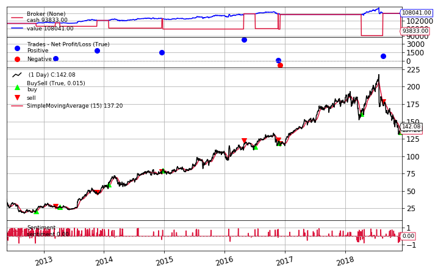

```python
ticker = 'FB'
date_sentiment=data_df[data_df['ticker'].isin([ticker])]
date_sentiment=date_sentiment[['date','sentiment_lex']]
date_sentiment['date']=pd.to_datetime(date_sentiment['date'], format='%Y-%m-%d').dt.date
date_sentiment=date_sentiment.set_index('date')['sentiment_lex']
date_sentiment=date_sentiment.to_dict()
run_strategy(ticker, start = '2012-01-01', end = '2018-12-12')
```

Top Panel : The CashValue shows overall profit of 8041.00.

Second Panel : A Trade Observer shows that six out of 7 actions are profitable.

Third Panel : A BuySell observer shows that in general the buy action takes place when the stock price is increasing and the sell action takes place when the stock price has started declining.

Forth Panel : It shows high number of positive sentiment for the FB around 2013 and 2014 period.

## 5.3. Results for Multiple Stocks

```
AAPL
Starting Portfolio Value: 100000.00
2013-12-13, Previous Sentiment -0.38, New Sentiment 0.86 BUY CREATE, 70.91
2013-12-16, BUY EXECUTED, Price: 70.99, Cost: 7099.00, Comm 0.00
2014-09-25, Previous Sentiment 0.78, New Sentiment 0.04 SELL CREATE, 89.08
2014-09-26, SELL EXECUTED, Price: 89.68, Cost: 7099.00, Comm 0.00
2014-09-26, OPERATION PROFIT, GROSS 1869.00, NET 1869.00
2014-10-21, Previous Sentiment 0.14, New Sentiment 0.68 BUY CREATE, 93.27
2014-10-22, BUY EXECUTED, Price: 93.61, Cost: 9361.00, Comm 0.00
2015-06-11, Previous Sentiment 0.48, New Sentiment -0.42 SELL CREATE, 118.51
2015-06-12, SELL EXECUTED, Price: 118.14, Cost: 9361.00, Comm 0.00
2015-06-12, OPERATION PROFIT, GROSS 2453.00, NET 2453.00
2015-09-14, Previous Sentiment 0.35, New Sentiment 0.95 BUY CREATE, 106.75
2015-09-15, BUY EXECUTED, Price: 107.33, Cost: 10733.00, Comm 0.00
2015-12-14, Previous Sentiment 0.24, New Sentiment -0.62 SELL CREATE, 104.58
2015-12-15, SELL EXECUTED, Price: 104.08, Cost: 10733.00, Comm 0.00
2015-12-15, OPERATION PROFIT, GROSS -325.00, NET -325.00
2016-03-15, Previous Sentiment 0.09, New Sentiment 0.66 BUY CREATE, 97.76
2016-03-16, BUY EXECUTED, Price: 97.79, Cost: 9779.00, Comm 0.00
2016-07-26, Previous Sentiment 0.93, New Sentiment 0.14 SELL CREATE, 90.92
2016-07-27, SELL EXECUTED, Price: 98.06, Cost: 9779.00, Comm 0.00
2016-07-27, OPERATION PROFIT, GROSS 27.00, NET 27.00
2016-12-13, Previous Sentiment 0.15, New Sentiment 0.74 BUY CREATE, 109.48
2016-12-14, BUY EXECUTED, Price: 109.34, Cost: 10934.00, Comm 0.00
2017-09-22, Previous Sentiment 0.58, New Sentiment 0.08 SELL CREATE, 146.16
2017-09-25, SELL EXECUTED, Price: 144.33, Cost: 10934.00, Comm 0.00
2017-09-25, OPERATION PROFIT, GROSS 3499.00, NET 3499.00
2017-11-06, Previous Sentiment 0.14, New Sentiment 0.64 BUY CREATE, 167.67
2017-11-07, BUY EXECUTED, Price: 167.35, Cost: 16735.00, Comm 0.00
2017-12-08, Previous Sentiment 0.57, New Sentiment -0.02 SELL CREATE, 163.56
2017-12-11, SELL EXECUTED, Price: 163.40, Cost: 16735.00, Comm 0.00
2017-12-11, OPERATION PROFIT, GROSS -395.00, NET -395.00
2017-12-13, Previous Sentiment -0.02, New Sentiment 0.71 BUY CREATE, 166.36
2017-12-14, BUY EXECUTED, Price: 166.49, Cost: 16649.00, Comm 0.00
2018-02-01, Previous Sentiment 0.66, New Sentiment 0.06 SELL CREATE, 162.03
2018-02-02, SELL EXECUTED, Price: 160.31, Cost: 16649.00, Comm 0.00
2018-02-02, OPERATION PROFIT, GROSS -618.00, NET -618.00
2018-03-01, Previous Sentiment -0.07, New Sentiment 0.85 BUY CREATE, 169.69
2018-03-02, BUY EXECUTED, Price: 167.56, Cost: 16756.00, Comm 0.00
2018-03-28, Previous Sentiment 0.60, New Sentiment 0.09 SELL CREATE, 161.43
2018-03-29, SELL EXECUTED, Price: 162.72, Cost: 16756.00, Comm 0.00
2018-03-29, OPERATION PROFIT, GROSS -484.00, NET -484.00
2018-04-11, Previous Sentiment -0.23, New Sentiment 0.66 BUY CREATE, 167.21
2018-04-12, BUY EXECUTED, Price: 168.15, Cost: 16815.00, Comm 0.00
2018-04-24, Previous Sentiment 0.89, New Sentiment -0.23 SELL CREATE, 157.99
2018-04-25, SELL EXECUTED, Price: 157.68, Cost: 16815.00, Comm 0.00
2018-04-25, OPERATION PROFIT, GROSS -1047.00, NET -1047.00
2018-10-01, Previous Sentiment -0.35, New Sentiment 0.75 BUY CREATE, 221.99
2018-10-02, BUY EXECUTED, Price: 221.98, Cost: 22198.00, Comm 0.00
2018-10-10, Previous Sentiment 0.52, New Sentiment -0.11 SELL CREATE, 211.34
2018-10-11, SELL EXECUTED, Price: 209.54, Cost: 22198.00, Comm 0.00
2018-10-11, OPERATION PROFIT, GROSS -1244.00, NET -1244.00
2018-12-11, (MA Period 15) Ending Value 103735.00
```

```
Start Portfolio value: 100000.00
Final Portfolio Value: 103735.00
Profit: 3735.00

MSFT
Starting Portfolio Value: 100000.00
2012-03-08, Previous Sentiment -0.50, New Sentiment 0.92 BUY CREATE, 26.43
2012-03-09, BUY EXECUTED, Price: 26.51, Cost: 2651.00, Comm 0.00
2012-04-04, Previous Sentiment 0.87, New Sentiment -0.42 SELL CREATE, 25.77
2012-04-05, SELL EXECUTED, Price: 25.72, Cost: 2651.00, Comm 0.00
2012-04-05, OPERATION PROFIT, GROSS -79.00, NET -79.00
2012-06-19, Previous Sentiment 0.15, New Sentiment 0.88 BUY CREATE, 25.52
2012-06-20, BUY EXECUTED, Price: 25.71, Cost: 2571.00, Comm 0.00
2012-07-12, Previous Sentiment 0.68, New Sentiment -0.65 SELL CREATE, 23.80
2012-07-13, SELL EXECUTED, Price: 23.90, Cost: 2571.00, Comm 0.00
2012-07-13, OPERATION PROFIT, GROSS -181.00, NET -181.00
2012-11-01, Previous Sentiment -0.69, New Sentiment 0.59 BUY CREATE, 24.70
2012-11-02, BUY EXECUTED, Price: 24.76, Cost: 2476.00, Comm 0.00
2012-11-13, Previous Sentiment 0.96, New Sentiment 0.13 SELL CREATE, 22.85
2012-11-14, SELL EXECUTED, Price: 22.98, Cost: 2476.00, Comm 0.00
2012-11-14, OPERATION PROFIT, GROSS -178.00, NET -178.00
2013-04-16, Previous Sentiment -0.74, New Sentiment 0.90 BUY CREATE, 24.64
2013-04-17, BUY EXECUTED, Price: 24.54, Cost: 2454.00, Comm 0.00
2013-07-29, Previous Sentiment 0.80, New Sentiment -0.30 SELL CREATE, 27.01
2013-07-30, SELL EXECUTED, Price: 27.22, Cost: 2454.00, Comm 0.00
2013-07-30, OPERATION PROFIT, GROSS 268.00, NET 268.00
2013-09-20, Previous Sentiment 0.25, New Sentiment 0.82 BUY CREATE, 28.28
2013-09-23, BUY EXECUTED, Price: 28.07, Cost: 2807.00, Comm 0.00
2013-10-24, Previous Sentiment 0.58, New Sentiment 0.01 SELL CREATE, 29.08
2013-10-25, SELL EXECUTED, Price: 30.95, Cost: 2807.00, Comm 0.00
2013-10-25, OPERATION PROFIT, GROSS 288.00, NET 288.00
2013-11-20, Previous Sentiment 0.18, New Sentiment 0.89 BUY CREATE, 32.22
2013-11-21, BUY EXECUTED, Price: 32.39, Cost: 3239.00, Comm 0.00
2014-01-07, Previous Sentiment 0.49, New Sentiment -0.23 SELL CREATE, 31.64
2014-01-08, SELL EXECUTED, Price: 31.29, Cost: 3239.00, Comm 0.00
2014-01-08, OPERATION PROFIT, GROSS -110.00, NET -110.00
2014-01-16, Previous Sentiment -0.76, New Sentiment 0.45 BUY CREATE, 32.06
2014-01-17, BUY EXECUTED, Price: 32.01, Cost: 3201.00, Comm 0.00
2014-07-31, Previous Sentiment 0.95, New Sentiment 0.01 SELL CREATE, 38.06
2014-08-01, SELL EXECUTED, Price: 38.10, Cost: 3201.00, Comm 0.00
```

[output cut: 215 more lines]

```
2016-01-26, OPERATION PROFIT, GROSS 2014.00, NET 2014.00
2018-12-11, (MA Period 15) Ending Value 102014.00
Start Portfolio value: 100000.00
Final Portfolio Value: 102014.00
Profit: 2014.00

TSLA
Starting Portfolio Value: 100000.00
2012-03-26, Previous Sentiment 0.30, New Sentiment 0.90 BUY CREATE, 37.40
2012-03-27, BUY EXECUTED, Price: 37.16, Cost: 3716.00, Comm 0.00
2012-09-10, Previous Sentiment 0.89, New Sentiment -0.33 SELL CREATE, 27.37
2012-09-11, SELL EXECUTED, Price: 27.76, Cost: 3716.00, Comm 0.00
2012-09-11, OPERATION PROFIT, GROSS -940.00, NET -940.00
2012-12-04, Previous Sentiment 0.22, New Sentiment 0.76 BUY CREATE, 33.90
2012-12-05, BUY EXECUTED, Price: 33.82, Cost: 3382.00, Comm 0.00
```

```
2013-02-21, Previous Sentiment 0.87, New Sentiment 0.04 SELL CREATE, 35.16
2013-02-22, SELL EXECUTED, Price: 35.72, Cost: 3382.00, Comm 0.00
2013-02-22, OPERATION PROFIT, GROSS 190.00, NET 190.00
2013-03-25, Previous Sentiment 0.32, New Sentiment 0.87 BUY CREATE, 37.53
2013-03-26, BUY EXECUTED, Price: 37.98, Cost: 3798.00, Comm 0.00
2013-09-12, Previous Sentiment 0.94, New Sentiment 0.28 SELL CREATE, 164.93
2013-09-13, SELL EXECUTED, Price: 162.77, Cost: 3798.00, Comm 0.00
2013-09-13, OPERATION PROFIT, GROSS 12479.00, NET 12479.00
2014-02-24, Previous Sentiment -0.27, New Sentiment 0.80 BUY CREATE, 217.65
2014-02-25, BUY EXECUTED, Price: 230.00, Cost: 23000.00, Comm 0.00
2014-03-18, Previous Sentiment 0.80, New Sentiment 0.11 SELL CREATE, 240.04
2014-03-19, SELL EXECUTED, Price: 241.39, Cost: 23000.00, Comm 0.00
2014-03-19, OPERATION PROFIT, GROSS 1139.00, NET 1139.00
2014-06-05, Previous Sentiment -0.08, New Sentiment 0.65 BUY CREATE, 206.90
2014-06-06, BUY EXECUTED, Price: 209.75, Cost: 20975.00, Comm 0.00
2014-07-07, Previous Sentiment 0.86, New Sentiment -0.77 SELL CREATE, 222.66
2014-07-08, SELL EXECUTED, Price: 218.65, Cost: 20975.00, Comm 0.00
2014-07-08, OPERATION PROFIT, GROSS 890.00, NET 890.00
2014-11-20, Previous Sentiment -0.01, New Sentiment 0.69 BUY CREATE, 248.71
2014-11-21, BUY EXECUTED, Price: 252.21, Cost: 25221.00, Comm 0.00
2014-12-01, Previous Sentiment 0.69, New Sentiment -0.33 SELL CREATE, 231.64
2014-12-02, SELL EXECUTED, Price: 234.57, Cost: 25221.00, Comm 0.00
2014-12-02, OPERATION PROFIT, GROSS -1764.00, NET -1764.00
2015-02-06, Previous Sentiment -0.49, New Sentiment 0.47 BUY CREATE, 217.36
2015-02-09, BUY EXECUTED, Price: 215.38, Cost: 21538.00, Comm 0.00
2015-03-06, Previous Sentiment 0.77, New Sentiment 0.27 SELL CREATE, 193.88
2015-03-09, SELL EXECUTED, Price: 194.39, Cost: 21538.00, Comm 0.00
2015-03-09, OPERATION PROFIT, GROSS -2099.00, NET -2099.00
2015-06-16, Previous Sentiment 0.01, New Sentiment 0.67 BUY CREATE, 253.12
2015-06-17, BUY EXECUTED, Price: 252.17, Cost: 25217.00, Comm 0.00
2015-08-24, Previous Sentiment 0.24, New Sentiment -0.79 SELL CREATE, 218.87
2015-08-25, SELL EXECUTED, Price: 230.52, Cost: 25217.00, Comm 0.00
2015-08-25, OPERATION PROFIT, GROSS -2165.00, NET -2165.00
2015-09-24, Previous Sentiment 0.17, New Sentiment 0.89 BUY CREATE, 263.12
2015-09-25, BUY EXECUTED, Price: 266.61, Cost: 26661.00, Comm 0.00
2015-10-16, Previous Sentiment 0.89, New Sentiment -0.32 SELL CREATE, 227.01
2015-10-19, SELL EXECUTED, Price: 226.50, Cost: 26661.00, Comm 0.00
2015-10-19, OPERATION PROFIT, GROSS -4011.00, NET -4011.00
2015-11-06, Previous Sentiment -0.22, New Sentiment 0.85 BUY CREATE, 232.36
2015-11-09, BUY EXECUTED, Price: 232.99, Cost: 23299.00, Comm 0.00
```

[output cut: 118 more lines]

```
2014-09-17, OPERATION PROFIT, GROSS 3367.00, NET 3367.00
2015-09-18, Previous Sentiment -0.01, New Sentiment 0.83 BUY CREATE, 81.25
2015-09-21, BUY EXECUTED, Price: 81.42, Cost: 8142.00, Comm 0.00
2015-12-10, Previous Sentiment 0.74, New Sentiment -0.01 SELL CREATE, 88.96
2015-12-11, SELL EXECUTED, Price: 92.51, Cost: 8142.00, Comm 0.00
2015-12-11, OPERATION PROFIT, GROSS 1109.00, NET 1109.00
2017-03-17, Previous Sentiment -0.01, New Sentiment 0.76 BUY CREATE, 127.01
2017-03-20, BUY EXECUTED, Price: 126.99, Cost: 12699.00, Comm 0.00
2018-10-15, Previous Sentiment 0.71, New Sentiment 0.09 SELL CREATE, 238.01
2018-10-16, SELL EXECUTED, Price: 252.50, Cost: 12699.00, Comm 0.00
2018-10-16, OPERATION PROFIT, GROSS 12551.00, NET 12551.00
2018-12-11, (MA Period 15) Ending Value 117027.00
Start Portfolio value: 100000.00
Final Portfolio Value: 117027.00
Profit: 17027.00
```

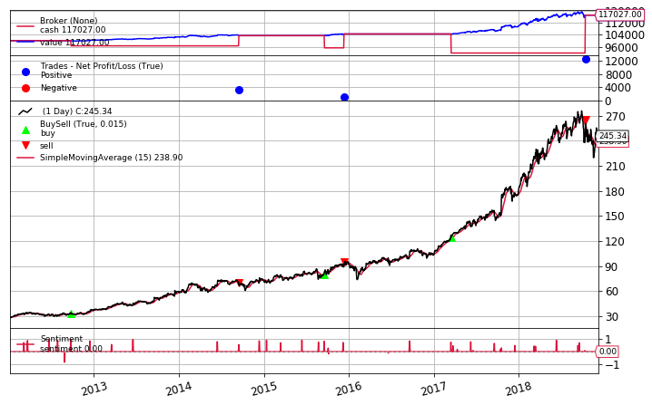

```python
results_tickers = {}
for ticker in tickers:
    date_sentiment=data_df[data_df['ticker'].isin([ticker])]
    date_sentiment=date_sentiment[['date','sentiment_lex']]
    date_sentiment['date']=pd.to_datetime(date_sentiment['date'], format='%Y-%m-%d').dt.date
    date_sentiment=date_sentiment.set_index('date')['sentiment_lex']
    date_sentiment=date_sentiment.to_dict()
    results_tickers[ticker] = run_strategy(ticker, start = '2012-01-01', end = '2018-12-12')
```

```python
pd.DataFrame.from_dict(results_tickers).set_index([pd.Index(["PerUnitStartPrice", 'StrategyProfit'])])
```

|  | AAPL | MSFT | AMZN | GOOG | FB | WMT | JPM | TSLA | NFLX | ADBE |
| --- | --- | --- | --- | --- | --- | --- | --- | --- | --- | --- |
| PerUnitStartPrice | 50.86 | 21.96 | 179.03 | 331.46 | 38.23 | 48.78 | 27.31 | 28.08 | 10.32 | 28.57 |
| StrategyProfit | 3735.00 | 4067.00 | 75377.00 | 49719.00 | 8041.00 | 1152.00 | 2014.00 | 15755.00 | 25181.00 | 17027.00 |

The strategy yield an overall profit be for all the stock. Now we run the strategy varying the time period.

## 5.4. Varying the strategy time period

In this step we run the strategy for differnt time periods and look at the results. We first run it for the time period between 2012 and 2014.

```
AAPL
Starting Portfolio Value: 100000.00
2013-12-13, Previous Sentiment -0.38, New Sentiment 0.86 BUY CREATE, 70.91
2013-12-16, BUY EXECUTED, Price: 70.99, Cost: 7099.00, Comm 0.00
2014-09-25, Previous Sentiment 0.78, New Sentiment 0.04 SELL CREATE, 89.08
2014-09-26, SELL EXECUTED, Price: 89.68, Cost: 7099.00, Comm 0.00
2014-09-26, OPERATION PROFIT, GROSS 1869.00, NET 1869.00
2014-10-21, Previous Sentiment 0.14, New Sentiment 0.68 BUY CREATE, 93.27
2014-10-22, BUY EXECUTED, Price: 93.61, Cost: 9361.00, Comm 0.00
2014-12-30, (MA Period 15) Ending Value 102794.00
```

```
Start Portfolio value: 100000.00
Final Portfolio Value: 102794.00
Profit: 2794.00

MSFT
Starting Portfolio Value: 100000.00
2012-03-08, Previous Sentiment -0.50, New Sentiment 0.92 BUY CREATE, 26.43
2012-03-09, BUY EXECUTED, Price: 26.51, Cost: 2651.00, Comm 0.00
2012-04-04, Previous Sentiment 0.87, New Sentiment -0.42 SELL CREATE, 25.77
2012-04-05, SELL EXECUTED, Price: 25.72, Cost: 2651.00, Comm 0.00
2012-04-05, OPERATION PROFIT, GROSS -79.00, NET -79.00
2012-06-19, Previous Sentiment 0.15, New Sentiment 0.88 BUY CREATE, 25.52
2012-06-20, BUY EXECUTED, Price: 25.71, Cost: 2571.00, Comm 0.00
2012-07-12, Previous Sentiment 0.68, New Sentiment -0.65 SELL CREATE, 23.80
2012-07-13, SELL EXECUTED, Price: 23.90, Cost: 2571.00, Comm 0.00
2012-07-13, OPERATION PROFIT, GROSS -181.00, NET -181.00
2012-11-01, Previous Sentiment -0.69, New Sentiment 0.59 BUY CREATE, 24.70
2012-11-02, BUY EXECUTED, Price: 24.76, Cost: 2476.00, Comm 0.00
2012-11-13, Previous Sentiment 0.96, New Sentiment 0.13 SELL CREATE, 22.85
2012-11-14, SELL EXECUTED, Price: 22.98, Cost: 2476.00, Comm 0.00
2012-11-14, OPERATION PROFIT, GROSS -178.00, NET -178.00
2013-04-16, Previous Sentiment -0.74, New Sentiment 0.90 BUY CREATE, 24.64
2013-04-17, BUY EXECUTED, Price: 24.54, Cost: 2454.00, Comm 0.00
2013-07-29, Previous Sentiment 0.80, New Sentiment -0.30 SELL CREATE, 27.01
2013-07-30, SELL EXECUTED, Price: 27.22, Cost: 2454.00, Comm 0.00
2013-07-30, OPERATION PROFIT, GROSS 268.00, NET 268.00
2013-09-20, Previous Sentiment 0.25, New Sentiment 0.82 BUY CREATE, 28.28
2013-09-23, BUY EXECUTED, Price: 28.07, Cost: 2807.00, Comm 0.00
2013-10-24, Previous Sentiment 0.58, New Sentiment 0.01 SELL CREATE, 29.08
2013-10-25, SELL EXECUTED, Price: 30.95, Cost: 2807.00, Comm 0.00
2013-10-25, OPERATION PROFIT, GROSS 288.00, NET 288.00
2013-11-20, Previous Sentiment 0.18, New Sentiment 0.89 BUY CREATE, 32.22
2013-11-21, BUY EXECUTED, Price: 32.39, Cost: 3239.00, Comm 0.00
2014-01-07, Previous Sentiment 0.49, New Sentiment -0.23 SELL CREATE, 31.64
2014-01-08, SELL EXECUTED, Price: 31.29, Cost: 3239.00, Comm 0.00
2014-01-08, OPERATION PROFIT, GROSS -110.00, NET -110.00
2014-01-16, Previous Sentiment -0.76, New Sentiment 0.45 BUY CREATE, 32.06
2014-01-17, BUY EXECUTED, Price: 32.01, Cost: 3201.00, Comm 0.00
2014-07-31, Previous Sentiment 0.95, New Sentiment 0.01 SELL CREATE, 38.06
2014-08-01, SELL EXECUTED, Price: 38.10, Cost: 3201.00, Comm 0.00
```

[output cut: 150 more lines]

```
Start Portfolio value: 100000.00
Final Portfolio Value: 102712.00
Profit: 2712.00

ADBE
Starting Portfolio Value: 100000.00
2012-09-20, Previous Sentiment -0.84, New Sentiment 0.97 BUY CREATE, 34.53
2012-09-21, BUY EXECUTED, Price: 34.36, Cost: 3436.00, Comm 0.00
2014-09-16, Previous Sentiment 0.81, New Sentiment 0.16 SELL CREATE, 70.73
2014-09-17, SELL EXECUTED, Price: 68.03, Cost: 3436.00, Comm 0.00
2014-09-17, OPERATION PROFIT, GROSS 3367.00, NET 3367.00
2014-12-30, (MA Period 15) Ending Value 103367.00
Start Portfolio value: 100000.00
Final Portfolio Value: 103367.00
Profit: 3367.00
```

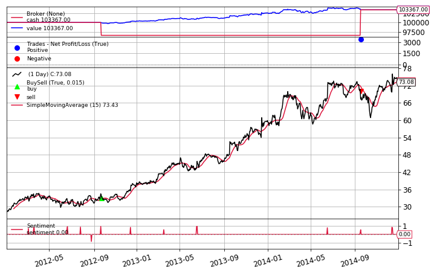

```python
results_tickers = {}
for ticker in tickers:
    date_sentiment=data_df[data_df['ticker'].isin([ticker])]
    date_sentiment=date_sentiment[['date','sentiment_lex']]
    date_sentiment['date']=pd.to_datetime(date_sentiment['date'], format='%Y-%m-%d').dt.date
    date_sentiment=date_sentiment.set_index('date')['sentiment_lex']
    date_sentiment=date_sentiment.to_dict()
    results_tickers[ticker] = run_strategy(ticker, start = '2012-01-01', end = '2014-12-31')
```

```python
pd.DataFrame.from_dict(results_tickers).set_index([pd.Index(["StockPriceBeginning", 'StrategyProfit'])])
```

|  | AAPL | MSFT | AMZN | GOOG | FB | WMT | JPM | TSLA | NFLX | ADBE |
| --- | --- | --- | --- | --- | --- | --- | --- | --- | --- | --- |
| StockPriceBeginning | 50.86 | 21.96 | 179.03 | 331.46 | 38.23 | 48.78 | 27.31 | 28.08 | 10.32 | 28.57 |
| StrategyProfit | 2794.00 | 617.00 | -2873.00 | 23191.00 | 3528.00 | -313.00 | 2472.00 | 11994.00 | 2712.00 | 3367.00 |

The strategy yield an overall profit for all the stocks except two. Now we run the strategy between 2016 and 2018.

```
AAPL
Starting Portfolio Value: 100000.00
2016-03-15, Previous Sentiment 0.09, New Sentiment 0.66 BUY CREATE, 97.76
2016-03-16, BUY EXECUTED, Price: 97.79, Cost: 9779.00, Comm 0.00
2016-07-26, Previous Sentiment 0.93, New Sentiment 0.14 SELL CREATE, 90.92
2016-07-27, SELL EXECUTED, Price: 98.06, Cost: 9779.00, Comm 0.00
2016-07-27, OPERATION PROFIT, GROSS 27.00, NET 27.00
2016-12-13, Previous Sentiment 0.15, New Sentiment 0.74 BUY CREATE, 109.48
2016-12-14, BUY EXECUTED, Price: 109.34, Cost: 10934.00, Comm 0.00
2017-09-22, Previous Sentiment 0.58, New Sentiment 0.08 SELL CREATE, 146.16
2017-09-25, SELL EXECUTED, Price: 144.33, Cost: 10934.00, Comm 0.00
2017-09-25, OPERATION PROFIT, GROSS 3499.00, NET 3499.00
2017-11-06, Previous Sentiment 0.14, New Sentiment 0.64 BUY CREATE, 167.67
2017-11-07, BUY EXECUTED, Price: 167.35, Cost: 16735.00, Comm 0.00
2017-12-08, Previous Sentiment 0.57, New Sentiment -0.02 SELL CREATE, 163.56
2017-12-11, SELL EXECUTED, Price: 163.40, Cost: 16735.00, Comm 0.00
2017-12-11, OPERATION PROFIT, GROSS -395.00, NET -395.00
2017-12-13, Previous Sentiment -0.02, New Sentiment 0.71 BUY CREATE, 166.36
2017-12-14, BUY EXECUTED, Price: 166.49, Cost: 16649.00, Comm 0.00
2018-02-01, Previous Sentiment 0.66, New Sentiment 0.06 SELL CREATE, 162.03
2018-02-02, SELL EXECUTED, Price: 160.31, Cost: 16649.00, Comm 0.00
2018-02-02, OPERATION PROFIT, GROSS -618.00, NET -618.00
2018-03-01, Previous Sentiment -0.07, New Sentiment 0.85 BUY CREATE, 169.69
2018-03-02, BUY EXECUTED, Price: 167.56, Cost: 16756.00, Comm 0.00
2018-03-28, Previous Sentiment 0.60, New Sentiment 0.09 SELL CREATE, 161.43
2018-03-29, SELL EXECUTED, Price: 162.72, Cost: 16756.00, Comm 0.00
2018-03-29, OPERATION PROFIT, GROSS -484.00, NET -484.00
2018-04-11, Previous Sentiment -0.23, New Sentiment 0.66 BUY CREATE, 167.21
2018-04-12, BUY EXECUTED, Price: 168.15, Cost: 16815.00, Comm 0.00
2018-04-24, Previous Sentiment 0.89, New Sentiment -0.23 SELL CREATE, 157.99
2018-04-25, SELL EXECUTED, Price: 157.68, Cost: 16815.00, Comm 0.00
2018-04-25, OPERATION PROFIT, GROSS -1047.00, NET -1047.00
2018-10-01, Previous Sentiment -0.35, New Sentiment 0.75 BUY CREATE, 221.99
2018-10-02, BUY EXECUTED, Price: 221.98, Cost: 22198.00, Comm 0.00
2018-10-10, Previous Sentiment 0.52, New Sentiment -0.11 SELL CREATE, 211.34
2018-10-11, SELL EXECUTED, Price: 209.54, Cost: 22198.00, Comm 0.00
2018-10-11, OPERATION PROFIT, GROSS -1244.00, NET -1244.00
2018-12-28, (MA Period 15) Ending Value 99738.00
```

```
Start Portfolio value: 100000.00
Final Portfolio Value: 99738.00
Profit: -262.00

MSFT
Starting Portfolio Value: 100000.00
2016-01-29, Previous Sentiment 0.01, New Sentiment 0.58 BUY CREATE, 50.52
2016-02-01, BUY EXECUTED, Price: 50.33, Cost: 5033.00, Comm 0.00
2016-02-04, Previous Sentiment 0.58, New Sentiment 0.01 SELL CREATE, 47.69
2016-02-05, SELL EXECUTED, Price: 47.64, Cost: 5033.00, Comm 0.00
2016-02-05, OPERATION PROFIT, GROSS -269.00, NET -269.00
2016-04-21, Previous Sentiment -0.47, New Sentiment 0.90 BUY CREATE, 51.52
2016-04-22, BUY EXECUTED, Price: 47.95, Cost: 4795.00, Comm 0.00
2016-04-28, Previous Sentiment 0.90, New Sentiment 0.01 SELL CREATE, 46.09
2016-04-29, SELL EXECUTED, Price: 45.59, Cost: 4795.00, Comm 0.00
2016-04-29, OPERATION PROFIT, GROSS -236.00, NET -236.00
2017-04-24, Previous Sentiment -0.08, New Sentiment 0.69 BUY CREATE, 64.02
2017-04-25, BUY EXECUTED, Price: 64.37, Cost: 6437.00, Comm 0.00
2017-12-05, Previous Sentiment 0.58, New Sentiment -0.19 SELL CREATE, 78.60
2017-12-06, SELL EXECUTED, Price: 78.56, Cost: 6437.00, Comm 0.00
2017-12-06, OPERATION PROFIT, GROSS 1419.00, NET 1419.00
2018-01-04, Previous Sentiment -0.29, New Sentiment 0.37 BUY CREATE, 83.92
2018-01-05, BUY EXECUTED, Price: 84.45, Cost: 8445.00, Comm 0.00
2018-10-09, Previous Sentiment 0.71, New Sentiment 0.01 SELL CREATE, 109.54
2018-10-10, SELL EXECUTED, Price: 108.55, Cost: 8445.00, Comm 0.00
2018-10-10, OPERATION PROFIT, GROSS 2410.00, NET 2410.00
2018-12-28, (MA Period 15) Ending Value 103324.00
Start Portfolio value: 100000.00
Final Portfolio Value: 103324.00
Profit: 3324.00

AMZN
Starting Portfolio Value: 100000.00
2016-02-29, Previous Sentiment 0.02, New Sentiment 0.88 BUY CREATE, 552.52
2016-03-01, BUY EXECUTED, Price: 556.29, Cost: 55629.00, Comm 0.00
2016-04-28, Previous Sentiment 0.96, New Sentiment 0.31 SELL CREATE, 602.00
2016-04-29, SELL EXECUTED, Price: 666.00, Cost: 55629.00, Comm 0.00
2016-04-29, OPERATION PROFIT, GROSS 10971.00, NET 10971.00
2016-05-10, Previous Sentiment 0.02, New Sentiment 0.57 BUY CREATE, 703.07
2016-05-11, BUY EXECUTED, Price: 705.79, Cost: 70579.00, Comm 0.00
```

[output cut: 183 more lines]

```
Start Portfolio value: 100000.00
Final Portfolio Value: 125020.00
Profit: 25020.00

ADBE
Starting Portfolio Value: 100000.00
2017-03-17, Previous Sentiment -0.01, New Sentiment 0.76 BUY CREATE, 127.01
2017-03-20, BUY EXECUTED, Price: 126.99, Cost: 12699.00, Comm 0.00
2018-10-15, Previous Sentiment 0.71, New Sentiment 0.09 SELL CREATE, 238.01
2018-10-16, SELL EXECUTED, Price: 252.50, Cost: 12699.00, Comm 0.00
2018-10-16, OPERATION PROFIT, GROSS 12551.00, NET 12551.00
2018-12-28, (MA Period 15) Ending Value 112551.00
Start Portfolio value: 100000.00
Final Portfolio Value: 112551.00
Profit: 12551.00
```

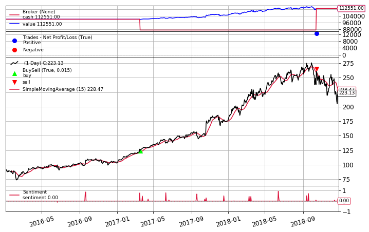

```python
results_tickers = {}
for ticker in tickers:
    date_sentiment=data_df[data_df['ticker'].isin([ticker])]
    date_sentiment=date_sentiment[['date','sentiment_lex']]
    date_sentiment['date']=pd.to_datetime(date_sentiment['date'], format='%Y-%m-%d').dt.date
    date_sentiment=date_sentiment.set_index('date')['sentiment_lex']
    date_sentiment=date_sentiment.to_dict()
    results_tickers[ticker] = run_strategy(ticker, start = '2016-01-01', end = '2018-12-31')
```

```python
pd.DataFrame.from_dict(results_tickers).set_index([pd.Index(["PerUnitStartPrice", 'StrategyProfit'])])
```

|  | AAPL | MSFT | AMZN | GOOG | FB | WMT | JPM | TSLA | NFLX | ADBE |
| --- | --- | --- | --- | --- | --- | --- | --- | --- | --- | --- |
| PerUnitStartPrice | 97.95 | 50.26 | 636.99 | 741.84 | 102.22 | 54.97 | 55.84 | 223.41 | 109.96 | 91.97 |
| StrategyProfit | -262.00 | 3324.00 | 67454.00 | 31430.00 | 648.00 | 657.00 | 0.00 | 10886.00 | 25020.00 | 12551.00 |

**Conclusion**